# Exercise 13.2

Lucia Camenisch

03 décembre 2022

First of all, we upload the necessary packages.

```r
library(data.table)   # data table, fread
library(ggplot2)      # plotting
library(gridExtra)    # arranging ggplots on a grid
library(dplyr)        # %>% function
library(tidyr)        # gather
library(e1071)        # skewness()
library(rpart)        # classification/regression trees
library(rpart.plot)   # plotting trees
library(caret)        # confusionMatrix(), preProcess() for scaling data
library(adabag)       # boosting() and bagging()
library(randomForest) # randomForest()

# sourcing homemade function for lift and decile charts
source("~/Documents/Travail/Business Analytics Master/Creating value through data mining/lift-decile-chart.R")

options(scipen = 999) # avoid scientific notation
```

We load our data, examine its structure using `str`, get a first idea of the variables distributions using `summary` and print a table of the number of unique values each variable takes.

```r
eBayAuctions <- fread("eBayAuctions.csv")                  # import data
str(eBayAuctions)                                          # data structure
```

```
## Classes 'data.table' and 'data.frame':   1972 obs. of  8 variables:
##  $ Category    : chr  "Music/Movie/Game" "Music/Movie/Game" "Music/Movie/Game" "Music/Movie/Game" ...
##  $ currency    : chr  "US" "US" "US" "US" ...
##  $ sellerRating: int  3249 3249 3249 3249 3249 3249 3249 3249 3249 3249 ...
##  $ Duration    : int  5 5 5 5 5 5 5 5 5 5 ...
##  $ endDay      : chr  "Mon" "Mon" "Mon" "Mon" ...
##  $ ClosePrice  : num  0.01 0.01 0.01 0.01 0.01 0.01 0.01 0.01 0.01 0.01 ...
##  $ OpenPrice   : num  0.01 0.01 0.01 0.01 0.01 0.01 0.01 0.01 0.01 0.01 ...
##  $ Competitive?: int  0 0 0 0 0 0 0 0 0 0 ...
##  - attr(*, ".internal.selfref")=<externalptr>
```

```r
summary(eBayAuctions)                                      # data summary
```

```
##    Category           currency          sellerRating      Duration
##  Length:1972        Length:1972        Min.   :    0   Min.   : 1.000
##  Class :character   Class :character   1st Qu.:  595   1st Qu.: 5.000
##  Mode  :character   Mode  :character   Median : 1853   Median : 7.000
##                                        Mean   : 3560   Mean   : 6.486
##                                        3rd Qu.: 3380   3rd Qu.: 7.000
##                                        Max.   :37727   Max.   :10.000
##     endDay            ClosePrice        OpenPrice       Competitive?
##  Length:1972        Min.   :  0.010   Min.   :  0.01   Min.   :0.0000
##  Class :character   1st Qu.:  4.907   1st Qu.:  1.23   1st Qu.:0.0000
##  Mode  :character   Median :  9.995   Median :  4.50   Median :1.0000
##                     Mean   : 36.449   Mean   : 12.93   Mean   :0.5406
##                     3rd Qu.: 28.000   3rd Qu.:  9.99   3rd Qu.:1.0000
##                     Max.   :999.000   Max.   :999.00   Max.   :1.0000
```

```r
t(t(sapply(eBayAuctions, function(x) length(unique(x)))))  # number of unique values
```

```
##              [,1]
## Category       18
## currency        3
## sellerRating  461
## Duration        5
## endDay          7
## ClosePrice    827
## OpenPrice     291
## Competitive?    2
```

We can already see that:

- `sellerRating`, `Duration`, `ClosePrice` and `OpenPrice` are numerical variables;
- `Category`, `currency` and `endDay` are categorical variables made of characters;
- `Competitive?` is a dummy variable.

The `eBayAuctions.csv` file isn’t described at the beginning of exercise 13.2. We will cite here the description which is given in Exercise 9.1. This gives us the context and defines the meaning of each variable.

*“The file `eBayAuctions.csv` contains information on 1972 auctions that transacted on eBay.com during May–June 2004. The goal is to use these data to build a model that will classify auctions as competitive or non-competitive. A competitive auction is defined as an auction with at least two bids placed on the item auctioned. The data include variables that describe the item (auction category), the seller (his/her eBay rating), and the auction terms that the seller selected (auction duration, opening price, currency, day-of-week of auction close). In addition, we have the price at which the auction closed. The task is to predict whether or not the auction will be competitive.”*

We check if there are any missing values in our data.

```r
t(t(colSums(is.na(eBayAuctions)))) #number of missing values in each column
```

```
##              [,1]
## Category        0
## currency        0
## sellerRating    0
## Duration        0
## endDay          0
## ClosePrice      0
## OpenPrice       0
## Competitive?    0
```

Fortunately, there aren’t any! Let us examine each variable more closely.

For our character variables, we list the values they take.

```r
# we show the unique values of each variable, sorting them by alphabetical order
sort(unique(eBayAuctions$Category))
```

```
##  [1] "Antique/Art/Craft"    "Automotive"           "Books"
##  [4] "Business/Industrial"  "Clothing/Accessories" "Coins/Stamps"
##  [7] "Collectibles"         "Computer"             "Electronics"
## [10] "EverythingElse"       "Health/Beauty"        "Home/Garden"
## [13] "Jewelry"              "Music/Movie/Game"     "Photography"
## [16] "Pottery/Glass"        "SportingGoods"        "Toys/Hobbies"
```

```r
sort(unique(eBayAuctions$currency))
```

```
## [1] "EUR" "GBP" "US"
```

```r
sort(unique(eBayAuctions$endDay))
```

```
## [1] "Fri" "Mon" "Sat" "Sun" "Thu" "Tue" "Wed"
```

For all three variables, the categories are in order. We have all days of the week, three known currencies and meaningful categories. There doesn’t appear to be any anomaly with values.

We will convert these variables to factors and plot their distributions.

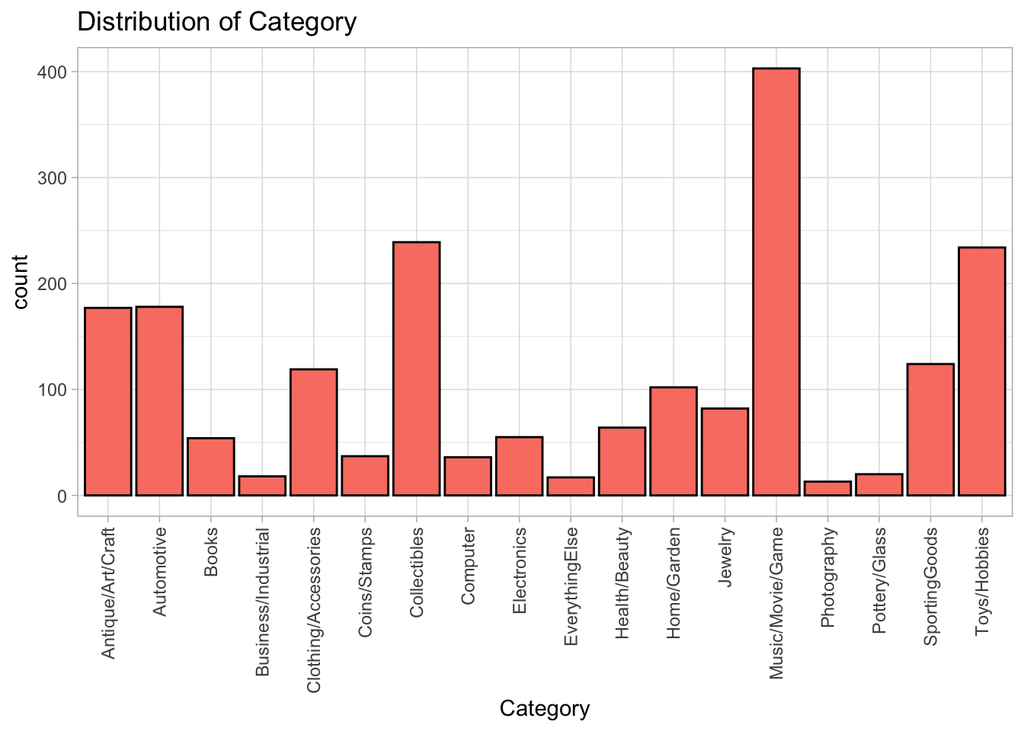

```r
# converting as factors
eBayAuctions$Category <- as.factor(eBayAuctions$Category)
eBayAuctions$currency <- as.factor(eBayAuctions$currency)
# endDay will be an ordered factor from monday to sunday
eBayAuctions$endDay   <- ordered(eBayAuctions$endDay,
                                 levels = c("Mon", "Tue", "Wed", "Thu", "Fri", "Sat", "Sun"))

# distribution of Category
ggplot(data = eBayAuctions, aes(Category)) +
  geom_bar(color = "black", fill = "#FA8072") +
  theme_light() +
  labs(title = "Distribution of Category") +
  # this rotates the text labels under x by 90°
  theme(axis.text.x = element_text(angle = 90, vjust = 0.5, hjust=1))
```

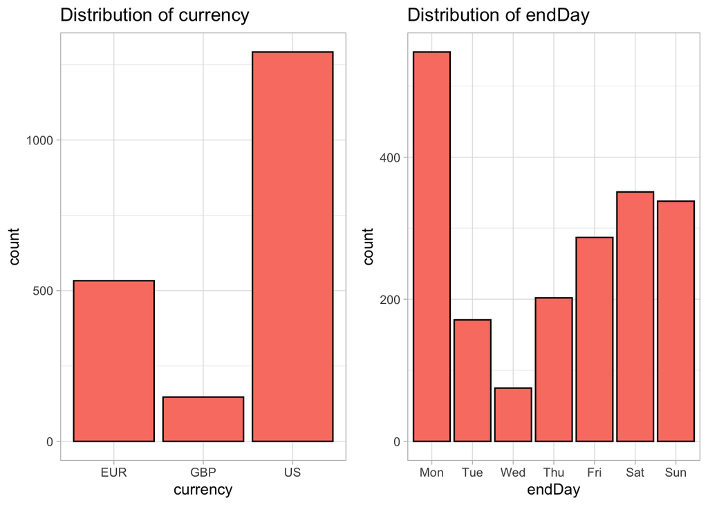

```r
# distribution of currency
plotCur <- ggplot(data = eBayAuctions, aes(currency)) +
  geom_bar(color = "black", fill = "#FA8072") +
  theme_light() +
  labs(title = "Distribution of currency")

# distribution of endDay
plotDay <- ggplot(data = eBayAuctions, aes(endDay)) +
  geom_bar(color = "black", fill = "#FA8072") +
  theme_light() +
  labs(title = "Distribution of endDay")

# we use grid.arrange from the gridExtra package to plot side by side
grid.arrange(plotCur, plotDay, ncol=2)
```

```r
# removing the plots from environment as they won't be used anymore
rm(plotCur, plotDay)
```

Now, we plot the distributions of the numerical variables.

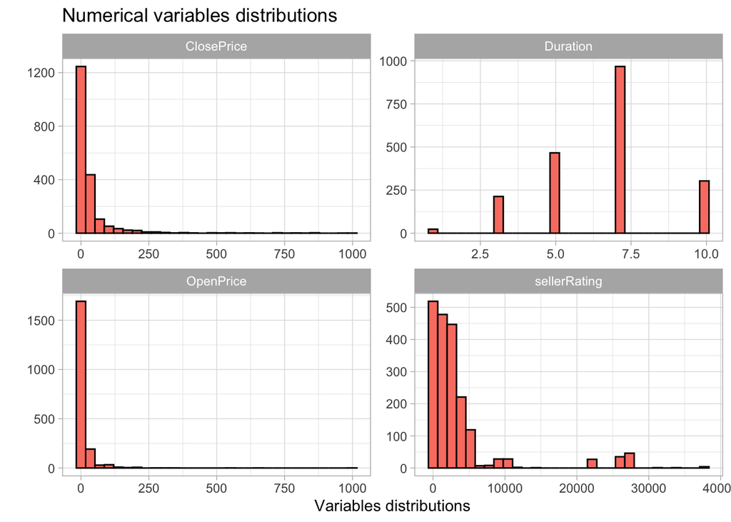

```r
eBayAuctions[, c(3,4,6,7)] %>% gather() %>%           # gather transforms data into two columns with
                                                      # "key" and "value"
  ggplot(aes(value)) +                                # plotting the value
  facet_wrap(~ key, scales = "free") +                # making one plot for each key with facet
  geom_histogram(color = "black", fill = "#FA8072") + # making histograms
  theme_light() +                                     # aesthetic theme for our plots
  labs(x = "Variables distributions", y = "",         # label of the figure
       title = "Numerical variables distributions")
```

We can immediately see that `sellerRating`, `OpenPrice` and `ClosePrice` seem very skewed. `Duration` does not. We use `skewness()` from the `e1071` package to check the skewness index of our four numerical variables.

We recall the criteria for the skewness index:

- **Around 0**: variable is symmetrical;
- **Above 0.5 in absolute value**: variable is moderately skewed;
- **Above 1 in absolute value**: variable is highly skewed.

```r
# sapply() allows to use skewness() on multiple columns of our data
sapply(eBayAuctions[, c(3,4,6,7)], skewness)
```

```
## sellerRating     Duration   ClosePrice    OpenPrice
##   3.21378117  -0.06321583   6.04803637  13.51295100
```

As we supposed, `Duration` isn’t skewed. However, the other three are all highly skewed!

We will transform them.

```r
# sellerRating had the lowest skewness index among the three, a 4th root is sufficient here
eBayAuctions$sellerRating <- eBayAuctions$sellerRating^(1/4)
# for ClosePrice and OpenPrice which are more skewed, we use the logarithm
# we add 1 to the values so the values remain positive (min of both variables is 0.1)
eBayAuctions$ClosePrice <- log(eBayAuctions$ClosePrice+1)
eBayAuctions$OpenPrice <- log(eBayAuctions$OpenPrice+1)

# we compute the skewness to see how it has evolved
sapply(eBayAuctions[, c(3,4,6,7)], skewness)
```

```
## sellerRating     Duration   ClosePrice    OpenPrice
##   0.47876332  -0.06321583   0.64180830   0.69164878
```

The skewness indexes are much better now! Our variables aren’t perfectly symmetrical, but they aren’t highly skewed anymore.

We plot the new distributions.

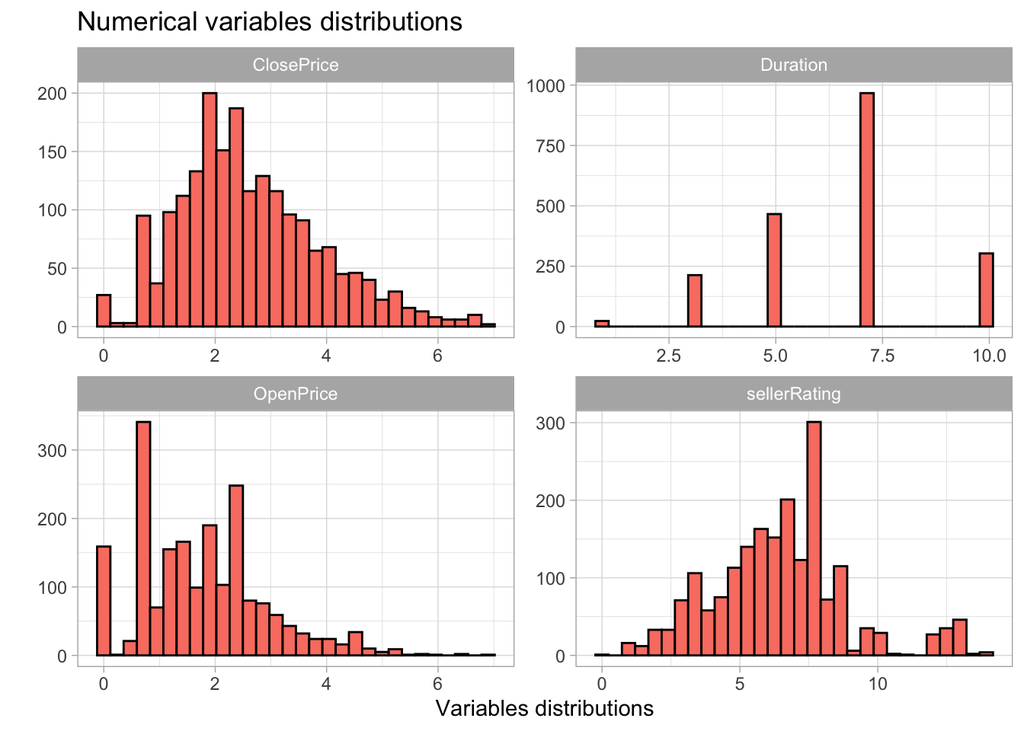

```r
eBayAuctions[, c(3,4,6,7)] %>% gather() %>%           # gather transforms data into two columns with
                                                      # "key" and "value"
  ggplot(aes(value)) +                                # plotting the value
  facet_wrap(~ key, scales = "free") +                # making one plot for each key with facet
  geom_histogram(color = "black", fill = "#FA8072") + # making histograms
  theme_light() +                                     # aesthetic theme for our plots
  labs(x = "Variables distributions", y = "",         # label of the figure
       title = "Numerical variables distributions")
```

Last, we plot the distribution of our dummy variable `Competitive?`. Before doing so, we will change its name to `Competitive` as the interrogation point is interpreted as a special character, forcing us to use the accents around the variable if we keep it.

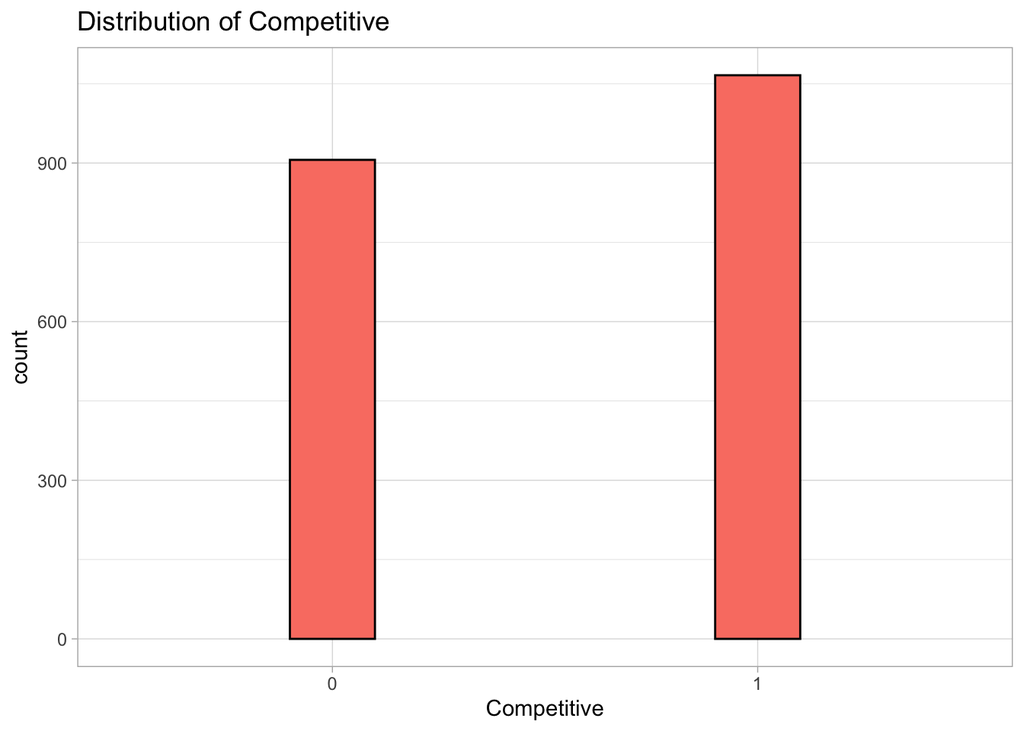

```r
# changing the column name
colnames(eBayAuctions)[8] <- "Competitive"
# transforming Competitive into a factor
eBayAuctions$Competitive <- as.factor(eBayAuctions$Competitive)
# plotting
ggplot(data = eBayAuctions, aes(Competitive)) +
  geom_bar(color = "black", fill = "#FA8072", width = 0.2) +
  theme_light() +
  labs(title = "Distribution of Competitive")
```

We can see that our dependent variable isn’t a rare characteristic! There are even more 1s than 0s.

Now, we will partition our data into training and validation sets.

```r
# set seed for reproducing the partition
set.seed(111)

# generating training set index
train.index <- sample(c(1:nrow(eBayAuctions)), 0.6*nrow(eBayAuctions))
# generating validation set index as the complementary of training set
valid.index <- setdiff(c(1:nrow(eBayAuctions)), train.index)

# creating data tables Train and Valid using the indexes
Train <- eBayAuctions[train.index, ]
Valid <- eBayAuctions[valid.index, ]

# removing indexes as they aren't used anymore
rm(train.index, valid.index)
```

# 1 Run a classification tree, using the default controls of `rpart()`.

We run the classification tree and plot it.

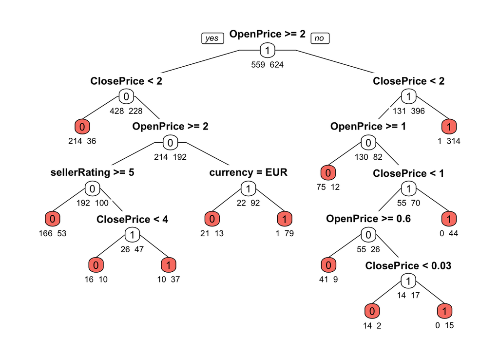

```r
# running the classification tree using the class method on training data
Tree <- rpart(Competitive ~ . , data = Train, method = "class")

# plotting the tree
prp(Tree, type = 1,                                                 # labels all nodes
    extra = 1,                                                      # displays n = ...
    varlen = -16,                                                   # number of chars of variables
    under = TRUE,                                                   # n = ... appears under node
    digits = -1,                                                    # avoid scientific notation
    box.col=ifelse(Tree$frame$var == "<leaf>", '#FA8072', 'white')) # coloring leaves in pink
```

We compute the confusion matrix on the validation set.

```r
# we first need the predictions of the validation set using the tree
# we create a data table in which we will store all predictions
Predictions = data.table(PredTree = predict(Tree, Valid, type = "class"))

# computing the confusion matrix (function is from caret package)
CMTree <- confusionMatrix(Predictions$PredTree, Valid$Competitive, positive = "1")
CMTree
```

```
## Confusion Matrix and Statistics
##
##           Reference
## Prediction   0   1
##          0 339 113
##          1   8 329
##
##                Accuracy : 0.8466
##                  95% CI : (0.8196, 0.8711)
##     No Information Rate : 0.5602
##     P-Value [Acc > NIR] : < 0.00000000000000022
##
##                   Kappa : 0.6986
##
##  Mcnemar's Test P-Value : < 0.00000000000000022
##
##             Sensitivity : 0.7443
##             Specificity : 0.9769
##          Pos Pred Value : 0.9763
##          Neg Pred Value : 0.7500
##              Prevalence : 0.5602
##          Detection Rate : 0.4170
##    Detection Prevalence : 0.4271
##       Balanced Accuracy : 0.8606
##
##        'Positive' Class : 1
##
```

The accuracy is equal to 0.8466413. It isn’t extremely good. We can also see that the sensitvity is low! We are missing 25% of true positives.

We display the lift and decile charts.

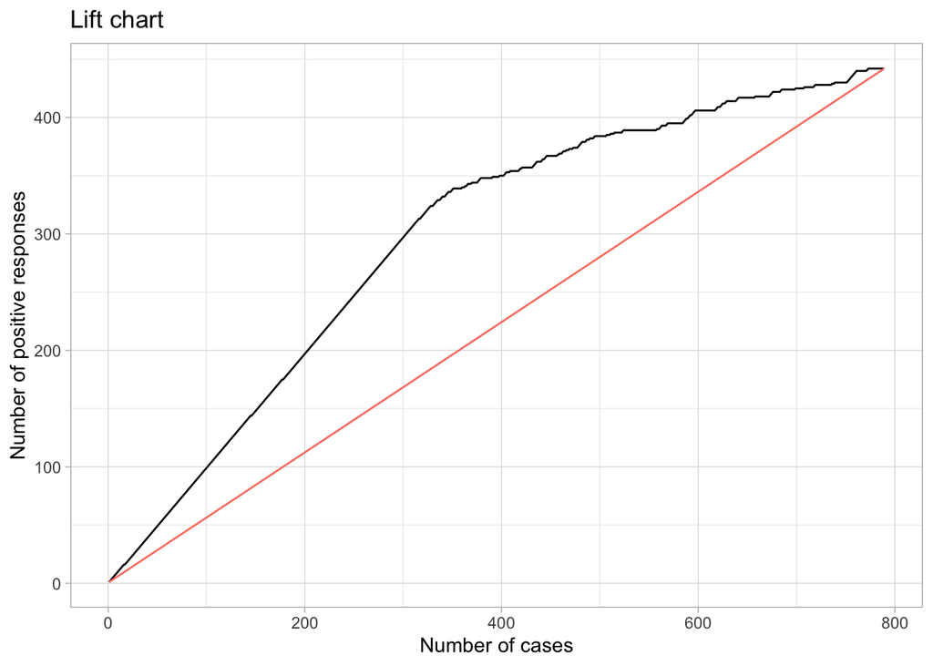

```r
# computing the probabilities of validation set
ProbTree <- predict(Tree, Valid, type = "prob")
# we only select the 2nd column (probabilities for Competitive = 1)
ProbTree <- ProbTree[, 2]
# we need the values of Competitive as numeric instead of factor, we convert them
lift.decile.chart(ProbTree, as.numeric(Valid$Competitive)-1, type = "lift")
```

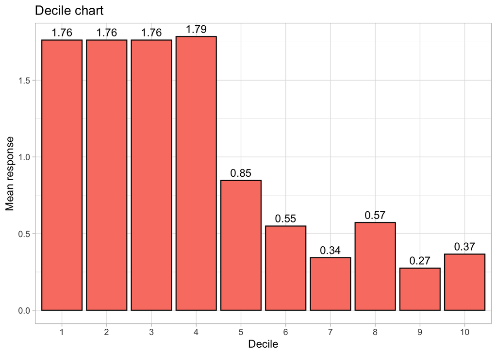

```r
lift.decile.chart(ProbTree, as.numeric(Valid$Competitive)-1, type = "decile")
```

```r
# we store ProbTree inside Predictions and remove it from our environment afterwards
Predictions <- Predictions[, ProbTree := ProbTree]
rm(ProbTree)
```

The lift of the first decile is of 1.76. This means that the mean response is equal to 1.76 times the mean response we would have taking cases at random.

# 2 Run a boosted tree with the same predictors (use function `boosting()` in the `adabag` package).

We run the boosted tree on the training set.

```r
TreeBoosted <- boosting(Competitive ~ . , data = Train)
```

We compute the confusion matrix of the validation set.

```r
# we first need the predictions of the validation set using boosting
# PredBoost is a list containing various elements. We can access the class and probas inside.
PredBoost = predict(TreeBoosted, Valid, type = "class")
# we get the class predictions and transform them into a factor
PredClassBoost = as.factor(PredBoost$class)
# we get the probabilities for Competitive = 1 (2nd column of prob inside PredBoost)
ProbBoost = PredBoost$prob[,2]
# we add PredBoost and ProbBoost to our Predictions table
Predictions[, PredBoost := PredClassBoost]
Predictions[, ProbBoost := ProbBoost]
# we remove the objects once information is stored inside Predictions
rm(PredBoost, PredClassBoost, ProbBoost)
# computing the confusion matrix (function is from caret package)
CMBoost <- confusionMatrix(Predictions$PredBoost, Valid$Competitive, positive = "1")
CMBoost
```

```
## Confusion Matrix and Statistics
##
##           Reference
## Prediction   0   1
##          0 331  55
##          1  16 387
##
##                Accuracy : 0.91
##                  95% CI : (0.8878, 0.9291)
##     No Information Rate : 0.5602
##     P-Value [Acc > NIR] : < 0.00000000000000022
##
##                   Kappa : 0.8196
##
##  Mcnemar's Test P-Value : 0.00000649
##
##             Sensitivity : 0.8756
##             Specificity : 0.9539
##          Pos Pred Value : 0.9603
##          Neg Pred Value : 0.8575
##              Prevalence : 0.5602
##          Detection Rate : 0.4905
##    Detection Prevalence : 0.5108
##       Balanced Accuracy : 0.9147
##
##        'Positive' Class : 1
##
```

The accuracy is equal to 0.9100127. It is already better than with the default tree. We can also see that the sensitivity has improved. It isn’t extremely high yet, but definitely better than before.

We compute the lift and decile charts for boosting.

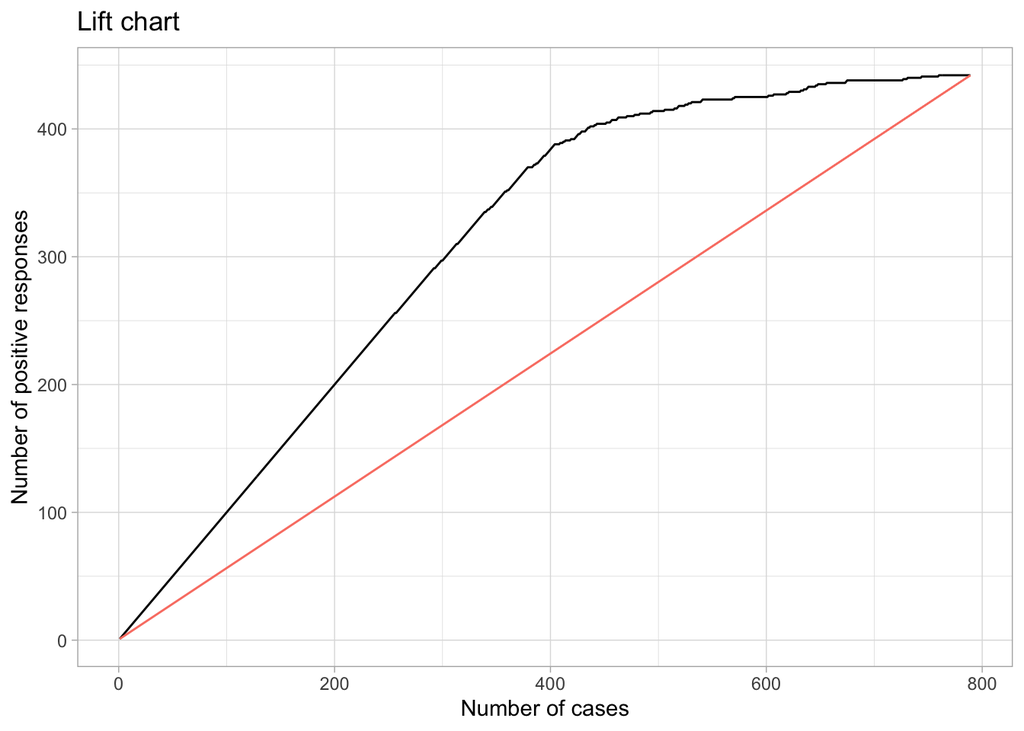

```r
lift.decile.chart(Predictions$ProbBoost, as.numeric(Valid$Competitive)-1, type = "lift")
```

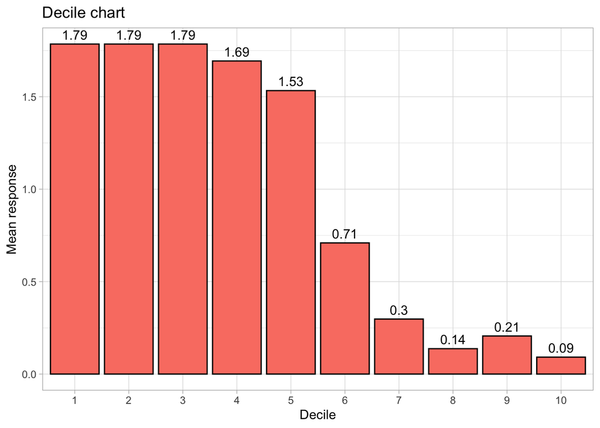

```r
lift.decile.chart(Predictions$ProbBoost, as.numeric(Valid$Competitive)-1, type = "decile")
```

The lift of the first decile is 1.79. It is very similar to the previous lift. However, the huge difference is in the fifth decile. We had a mean response of 0.85 before, and it became 1.53! This means that the fifth decile went from under-performing to over-performing with respect to the mean response of picking cases at random.

# 3 Run a bagged tree with the same predictors (use function `bagging()` in the `adabag` package).

We run the bagged tree on the training set.

```r
TreeBagged <- bagging(Competitive ~ . , data = Train)
```

We compute the confusion matrix of the validation set.

```r
# we first need the predictions of the validation set using bagging
# PredBag is a list containing various elements. We can access the class and probas inside.
PredBag = predict(TreeBagged, Valid, type = "class")
# we get the class predictions and transform them into a factor
PredClassBag = as.factor(PredBag$class)
# we get the probabilities for Competitive = 1 (2nd column of prob inside PredBoost)
ProbBag = PredBag$prob[,2]
# we add PredBoost and ProbBoost to our Predictions table
Predictions[, PredBag := PredClassBag]
Predictions[, ProbBag := ProbBag]
# we remove the objects once information is stored inside Predictions
rm(PredBag, PredClassBag, ProbBag)
# computing the confusion matrix (function is from caret package)
CMBag <- confusionMatrix(Predictions$PredBag, Valid$Competitive, positive = "1")
CMBag
```

```
## Confusion Matrix and Statistics
##
##           Reference
## Prediction   0   1
##          0 329 105
##          1  18 337
##
##                Accuracy : 0.8441
##                  95% CI : (0.8169, 0.8687)
##     No Information Rate : 0.5602
##     P-Value [Acc > NIR] : < 0.00000000000000022
##
##                   Kappa : 0.6919
##
##  Mcnemar's Test P-Value : 0.000000000000008879
##
##             Sensitivity : 0.7624
##             Specificity : 0.9481
##          Pos Pred Value : 0.9493
##          Neg Pred Value : 0.7581
##              Prevalence : 0.5602
##          Detection Rate : 0.4271
##    Detection Prevalence : 0.4499
##       Balanced Accuracy : 0.8553
##
##        'Positive' Class : 1
##
```

The accuracy is equal to 0.8441065. It’s nearly identical to the default tree. The sensitivity is also close to the default tree, performing only approximately 2% better. Boosting seems to be working much better than bagging here.

We compute the lift and decile charts for bagging

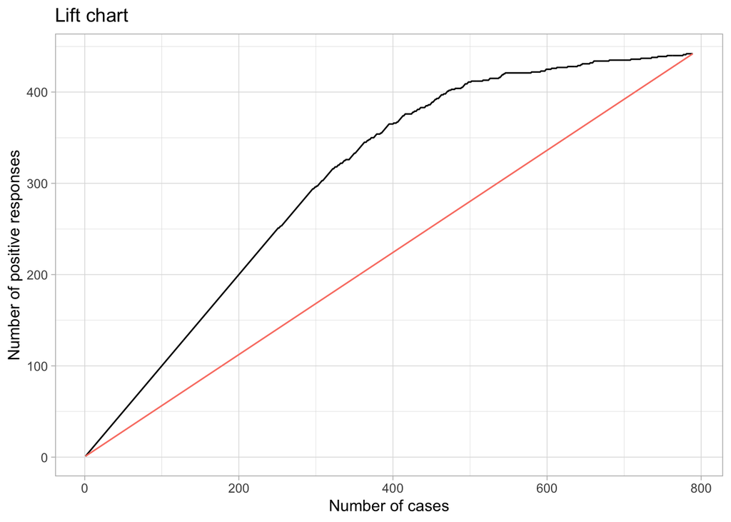

```r
lift.decile.chart(Predictions$ProbBag, as.numeric(Valid$Competitive)-1, type = "lift")
```

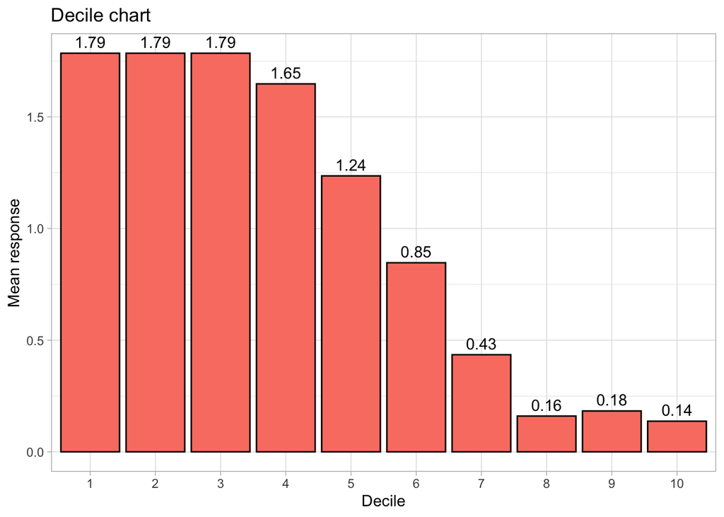

```r
lift.decile.chart(Predictions$ProbBag, as.numeric(Valid$Competitive)-1, type = "decile")
```

The lift of the first decile is 1.79. It is very close to the other two lifts. Here, the fifth decile is at 1.24, meaning it performs better than the random mean response, but it is still smaller than 1.53 (the value we had for boosting).

# 4 Run a random forest (use function `randomForest()` in package `randomForest` with argument `mtry = 4`).

We run the random forest.

```r
RandomForest <- randomForest(Competitive ~ . , data = Train, mtry = 4)
```

We compute the confusion matrix for the random forest.

```r
# we add the predicted classes to Prediction
Predictions[, RFPred := predict(RandomForest, Valid, type = "class")]
# we compute the predicted probabilities
RFProb <- predict(RandomForest, Valid, type = "prob")
# we add the predicted probabilities for class 1 (2nd column) to Predictions
Predictions[, RFProb := RFProb[, 2]]
# we remove the object now that it is stored inside predictions
rm(RFProb)
# we compute the confusion matrix
CMRF <- confusionMatrix(Predictions$RFPred, Valid$Competitive, positive = "1")
CMRF
```

```
## Confusion Matrix and Statistics
##
##           Reference
## Prediction   0   1
##          0 323  59
##          1  24 383
##
##                Accuracy : 0.8948
##                  95% CI : (0.8713, 0.9153)
##     No Information Rate : 0.5602
##     P-Value [Acc > NIR] : < 0.0000000000000002
##
##                   Kappa : 0.7888
##
##  Mcnemar's Test P-Value : 0.00019
##
##             Sensitivity : 0.8665
##             Specificity : 0.9308
##          Pos Pred Value : 0.9410
##          Neg Pred Value : 0.8455
##              Prevalence : 0.5602
##          Detection Rate : 0.4854
##    Detection Prevalence : 0.5158
##       Balanced Accuracy : 0.8987
##
##        'Positive' Class : 1
##
```

The accuracy is equal to 0.8948035. It is better than default and bagging accuracies, but slightly lower than the one of boosting. It’s the same for sensitivity, it’s close the the one of boosting but slightly lower.

We compute the lift and decile charts for our random forest.

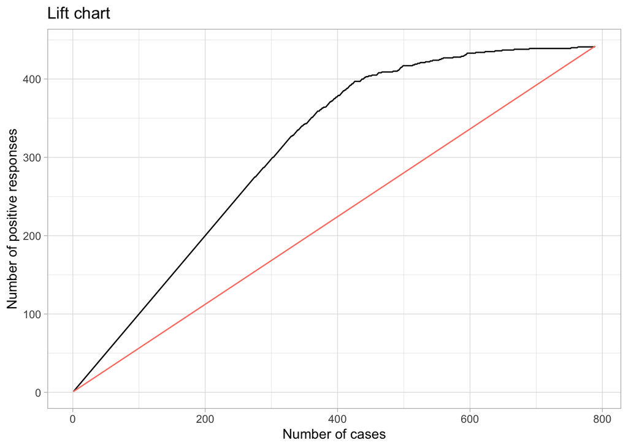

```r
lift.decile.chart(Predictions$RFProb, as.numeric(Valid$Competitive)-1, type = "lift")
```

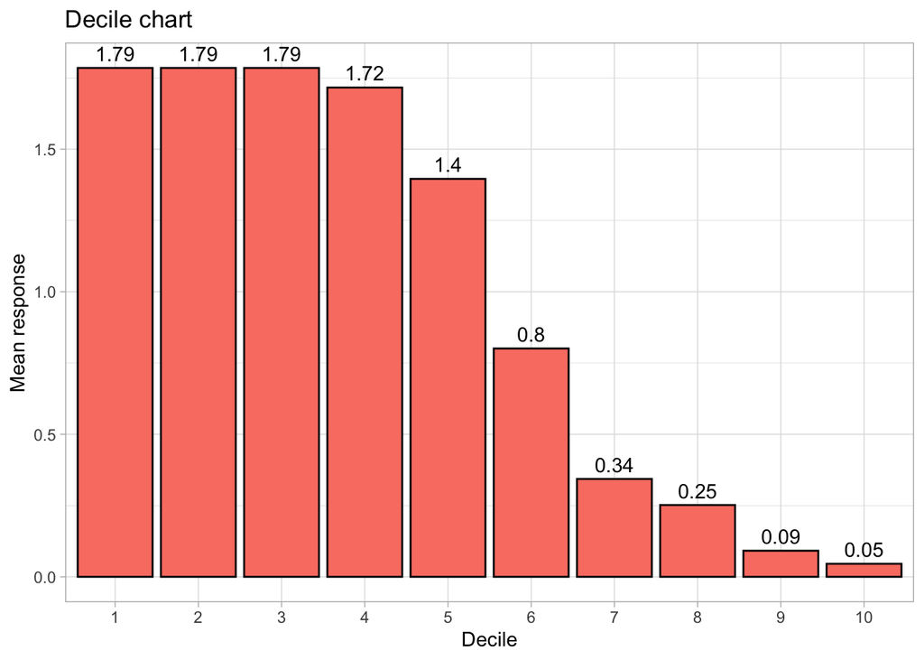

```r
lift.decile.chart(Predictions$RFProb, as.numeric(Valid$Competitive)-1, type = "decile")
```

Overall, the random forest performs better than the bagged tree. The two methods are conceptually very close, but there is one difference.

Random forests follow the same process but with an additional twist. At each split of each tree, instead of choosing from all the predictors, the next split is chosen from a sample of some of the predictors. Here, the parameter `mtry` controls how many variables are in the sample (so in our case, it was four predictor variables).

This difference is important as it means that unlike in bagging, where we produced $N$ copies of the same tree, in random forests, each tree will be different, as the splits won’t be made on the same variables from one tree to another. Hence the name random **forest**!